# mean_squared_error

**sklearn.metrics.mean_squared_error(*y_true*, *y_pred*, *, *sample_weight=None*, *multioutput='uniform_average'*)[[source]](https://github.com/scikit-learn/scikit-learn/blob/cc50648cc/sklearn/metrics/_regression.py#L515)**

Mean squared error regression loss.

Read more in the User Guide.

**Parameters:**

**y_true**array-like of shape (n_samples,) or (n_samples, n_outputs)**

Ground truth (correct) target values.

**y_pred**array-like of shape (n_samples,) or (n_samples, n_outputs)**

Estimated target values.

**sample_weight**array-like of shape (n_samples,), default=None**

Sample weights.

**multioutput**{‘raw_values’, ‘uniform_average’} or array-like of shape (n_outputs,), default=’uniform_average’**

Defines aggregating of multiple output values. Array-like value defines weights used to average errors.

**‘raw_values’ :**

Returns a full set of errors in case of multioutput input.

**‘uniform_average’ :**

Errors of all outputs are averaged with uniform weight.

**Returns:**

**loss**float or array of floats**

A non-negative floating point value (the best value is 0.0), or an array of floating point values, one for each individual target.

#### Examples

```
>>> from sklearn.metrics import mean_squared_error
>>> y_true = [3, -0.5, 2, 7]
>>> y_pred = [2.5, 0.0, 2, 8]
>>> mean_squared_error(y_true, y_pred)
0.375
>>> y_true = [[0.5, 1],[-1, 1],[7, -6]]
>>> y_pred = [[0, 2],[-1, 2],[8, -5]]
>>> mean_squared_error(y_true, y_pred)
0.708...
>>> mean_squared_error(y_true, y_pred, multioutput='raw_values')
array([0.41666667, 1.        ])
>>> mean_squared_error(y_true, y_pred, multioutput=[0.3, 0.7])
0.825...
```

## Gallery examples

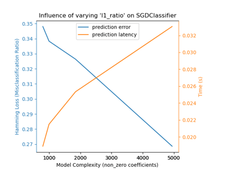

Model Complexity Influence

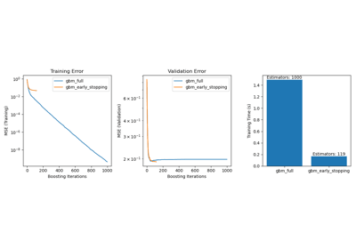

Early stopping in Gradient Boosting

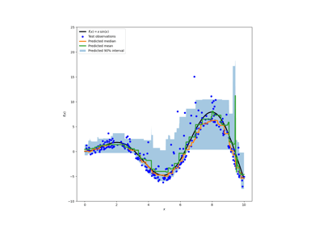

Prediction Intervals for Gradient Boosting Regression

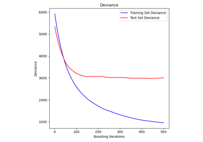

Gradient Boosting regression

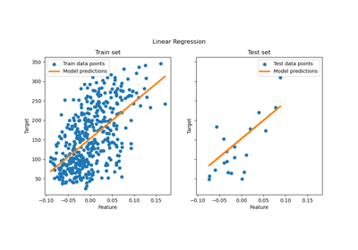

Ordinary Least Squares and Ridge Regression

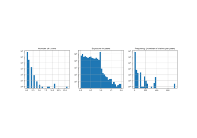

Poisson regression and non-normal loss

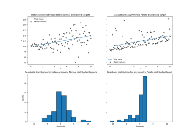

Quantile regression

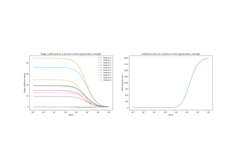

Ridge coefficients as a function of the L2 Regularization

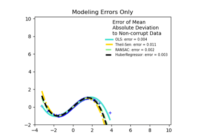

Robust linear estimator fitting

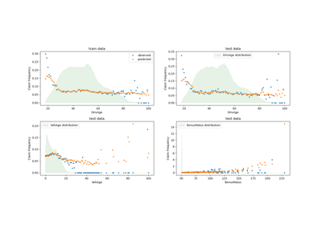

Tweedie regression on insurance claims